# SWIFT spatial: spatial autocorrelation

Christine Tedijanto christine.tedijanto@ucsf.edu

Last updated: 09/23/2021, cleaned: 02/24/2022

**Objective:** Explore spatial autocorrelation in trachoma indicators in preparation for model building.

```r
library(here)
source(here("0-config.R"))

# read in data
clu_random_0to5 <- readRDS(file = here(data_path, "clu_random_modeldata_public.rds")) %>%
  rename(cluster_id = cluster_id_public) %>%
  filter(age_group == "0-5y")

# setup dataframes
clu_random_0to5_sf <- clu_random_0to5 %>%
  st_as_sf(coords = c("lon", "lat"),
           remove = FALSE, crs = swift_crs)

clu_sf <- clu_random_0to5_sf %>%
  distinct(cluster_id, geometry)
```

### Moran’s I

Moran’s I measures global spatial autocorrelation (i.e. how similar one point is to others around it). Like a correlation coefficient, Moran’s I ranges from -1 to 1. The expected value of Moran’s I is slightly negative, approaching zero with increasing sample size. GeoDa (by Luc Anselin, et al.) has a helpful resource on Moran’s I [here](https://geodacenter.github.io/workbook/5a_global_auto/lab5a.html). Inference can be conducted under an assumption of normality (shown here) or by permutation (see `.Rmd` for figures).

```r
get_moran <- function(outcome_var, curr_survey){

  temp_df <- clu_random_0to5 %>%
    filter(survey == curr_survey)

  # distance method below based on code from spatial epi in R: https://hughst.github.io/week-4/
  # create symmetric matrix of distances between every point
  # dist_matrix <- temp_df %>%
  #   dplyr::select(lon, lat) %>%
  #   dist() %>%
  #   as.matrix()

  # updated to distGeo distance method, which accounts for globe surface
  # gives very similar Moran's I results to dist()
  temp_spatial <- temp_df %>%
    st_as_sf(coords = c("lon", "lat"), crs = swift_crs) %>%
    as("Spatial")

  dist_matrix <- sapply(1:nrow(temp_spatial),
                        function(x) geosphere::distGeo(p1 = temp_spatial, p2 = temp_spatial[x,]))

  # take inverse of distances
  dist_matrix_inv <- 1/dist_matrix
  diag(dist_matrix_inv) <- 0

  # estimate Moran's I and statistical significance for each trachoma variable
  ret <- ape::Moran.I(temp_df %>% pull(outcome_var), dist_matrix_inv) %>%
    as.data.frame() %>%
    mutate(outcome_var = outcome_var, curr_survey = curr_survey)

  return(ret)
}

moran_results <- mapply(get_moran,
                     outcome_var = rep(c("prevalence_sero", "prevalence_clin", "prevalence_pcr"), each = 4),
                     curr_survey = rep(survey_list, 3),
                     SIMPLIFY = FALSE) %>%
  bind_rows() %>%
  mutate_at(vars(-c("outcome_var")), as.numeric)

# summarize results in table
knitr::kable(x = moran_results %>% dplyr::select(outcome_var, curr_survey, observed, p.value),
  caption = "Global Moran's I by trachoma indicator",
  col.names = c("trachoma indicator", "survey month", "global Moran's I", "p-value"),
  digits = 4)
```

Global Moran’s I by trachoma indicator

| trachoma indicator | survey month | global Moran’s I | p-value |
| --- | --- | --- | --- |
| prevalence_sero | 0 | 0.0206 | 0.2185 |
| prevalence_sero | 12 | 0.0017 | 0.4694 |
| prevalence_sero | 24 | 0.0053 | 0.4133 |
| prevalence_sero | 36 | 0.0252 | 0.1758 |
| prevalence_clin | 0 | 0.0196 | 0.2276 |
| prevalence_clin | 12 | 0.0375 | 0.0930 |
| prevalence_clin | 24 | 0.0372 | 0.0858 |
| prevalence_clin | 36 | -0.0072 | 0.6221 |
| prevalence_pcr | 0 | 0.0041 | 0.4273 |
| prevalence_pcr | 12 | 0.0064 | 0.3885 |
| prevalence_pcr | 24 | 0.0350 | 0.1093 |
| prevalence_pcr | 36 | 0.0649 | 0.0175 |

### Variograms

```r
# create SpatialPointsDataFrame for clusters to allow for variogram building
clu_spatial <- clu_sf %>%
  st_as_sf(coords = c("lon", "lat"), crs = swift_crs) %>%
  as("Spatial")

# rule of thumb: limit max distance in variogram to half of maximum interpoint distance
clu_distances <- sapply(1:nrow(clu_spatial), function(x) geosphere::distGeo(p1 = clu_spatial, p2 = clu_spatial[x,])) # estimate distance from each point to all other points
max_dist <- max(clu_distances) / 2 / 1000 # divide by 1000 to turn meters to km (33.26 km)

## `get_variogram`: function to estimate variograms, fitted models, and monte carlo envelopes
# input_df: input dataframe
# input_formula: formula for variogram estimation
# input_survey: survey time point to concentrate on
# input_model: model to fit to variogram (default = "Exp")
# return line, fit (sserr), effective range, and empirical values (exp_var) for variograms
get_variogram <- function(input_df, input_formula, input_survey, input_model = "Exp"){

  # create temporary spatial dataframe based on inputs
  temp_spatial <- input_df %>%
    filter(survey == input_survey) %>%
    st_as_sf(coords = c("lon", "lat"), remove = FALSE, crs = swift_crs) %>%
    as("Spatial")

  ## get variogram model fits
  # note that automap creates fewer, but larger bins than gstat (gstat results were much more unstable)
  # note: `dist` in results is the average distance of all pairs in that bin (see `gstat` documentation)
  temp_fit <- automap::autofitVariogram(formula = as.formula(input_formula),
                                        input_data = temp_spatial,
                                        model = input_model, # ability to fit multiple models at once is deprecated?
                                        kappa = c(1.5, 2.5, 3.5, 5, 10, 15, 20), # only used for Matern
                                        # miscFitOptions = list(merge.small.bins = TRUE) # alternative way to create larger bins
                                        miscFitOptions = list(min.np.bin = 10)) # automap has this feature, gstat does not
  temp_var_model <- temp_fit$var_model

  # save values for fitted model
  temp_line <- gstat::variogramLine(temp_var_model, maxdist = max_dist)
  variog_line <- temp_line %>% mutate(formula = input_formula, survey = input_survey, model = input_model)

  # estimate effective range using nugget + 95% of sill
  temp_sill <- temp_var_model[which(temp_var_model$model == input_model), "psill"]
  temp_nugget <- temp_var_model[which(temp_var_model$model == "Nug"), "psill"]
  temp_effrange_y <- temp_sill*0.95 + temp_nugget
  temp_effrange <- ifelse(max(temp_line$gamma) < temp_effrange_y,
                          NA,
                          temp_line$dist[min(which(temp_line$gamma >= temp_effrange_y))])
  variog_stats <- data.frame(formula = input_formula, survey = input_survey, model = input_model,
                             sserr = temp_fit$sserr, effrange = temp_effrange)

  # save values for empirical variogram
  variog_expvar <- temp_fit$exp_var %>% dplyr::select(np, dist, gamma) %>%
    mutate(formula = input_formula, survey = input_survey, model = input_model)

  ret <- list(variog_line = variog_line,
              variog_stats = variog_stats,
              variog_expvar = variog_expvar)

  return(ret)
}

## `geo_perm`: helper function to conduct permutations
# input_df: input dataframe
# input_seed: for replication of permutations
# return permuted df - fixed lat/lon values, permuted outcomes
geo_perm <- function(input_df, input_seed){
  fix_locations <- input_df %>%
    dplyr::select(lon, lat)

  set.seed(input_seed)
  temp_permute <- input_df %>%
    dplyr::select(-c(lon, lat)) %>%
    sample_n(size = nrow(.), replace = FALSE)

  return(bind_cols(fix_locations, temp_permute))
}

## `get_variog_perms`: function to conduct Monte Carlo variogram permutations
# input_df: input dataframe
# input_formula: formula for variogram estimation
# input_survey: survey time point to concentrate on
# n_permute: number of permutations, must be >0
# return empirical values (exp_var) and 95% interval for permutations
get_variog_perms <- function(input_df, input_formula, input_survey, n_permute){

  # keep track of seeds; return list for replication
  rand_seed_list <- sample(1:10000, size = n_permute, replace = TRUE)

  permute_results <- lapply(
    c(1:n_permute),
    function(x){
      rand_seed <- rand_seed_list[x]

      temp_permute_df <- geo_perm(input_df = input_df %>% filter(survey == input_survey),
                                  input_seed = rand_seed)

      temp_permute_variog <- get_variogram(input_df = temp_permute_df,
                                           input_formula = input_formula,
                                           input_survey = input_survey)

      temp_permute_variog$variog_expvar %>% rename(!!paste0("gamma_", x) := gamma)
      }) %>%
    reduce(left_join, by = c("np", "dist", "formula", "survey", "model"))

  # add observed results
  variog_results <- get_variogram(input_df = input_df %>% filter(survey == input_survey),
                                  input_formula = input_formula,
                                  input_survey = input_survey)

  permute_results <- permute_results %>%
    left_join(variog_results$variog_expvar %>% rename(gamma_0 = gamma),
              by = c("np", "dist", "formula", "survey", "model"))

  # get upper and lower bounds for 95% envelope
  permute_bounds <- apply(permute_results %>% dplyr::select(starts_with("gamma")), 1, quantile, c(0.025, 0.975)) %>%
    t() %>%
    as.data.frame() %>%
    rename(q0.025 = "2.5%", q0.975 = "97.5%") %>%
    mutate(fill_flag = "1") # used for creating ggplot legend

  ret <- list(permute_results = permute_results %>%
                bind_cols(permute_bounds) %>%
                dplyr::select(-c(model)), # note that model is not important for permutations, uses only empirical
              rand_seed_list = rand_seed_list)

  return(ret)
}
```

**Estimate variograms and run permutations:**

```r
## iterate through formulas, surveys, and models
# 200 permutations takes ~1.1 minutes per formula
# 1000 permutations takes ~6.1 minutes per formula
n_permute_variog <- 1000
variog_formula_list <- c("prevalence_pcr~1", "prevalence_sero~1", "prevalence_clin~1",
                         "prevalence_pcr~lat+lon", "prevalence_sero~lat+lon", "prevalence_clin~lat+lon")
variog_results <- mapply(get_variogram,
                         input_formula = rep(variog_formula_list, each = 8),
                         input_survey = rep(rep(survey_list, 2), 6),
                         input_model = rep(rep(c("Mat", "Exp"), each = 4), 6),
                         MoreArgs = list(input_df = clu_random_0to5),
                         SIMPLIFY = TRUE)

variog_perm_results <- mapply(get_variog_perms,
                              input_formula = rep(variog_formula_list, each = 4),
                              input_survey = rep(survey_list, 6),
                              n_permute = n_permute_variog,
                              MoreArgs = list(input_df = clu_random_0to5),
                              SIMPLIFY = TRUE)

variog_line_df <- variog_results[1,] %>% bind_rows()
variog_stats_df <- variog_results[2,] %>% bind_rows()
variog_expvar_df <- variog_results[3,] %>% bind_rows()
variog_perm_results_df <- variog_perm_results[1,] %>% bind_rows()
```

**Plot variograms:**

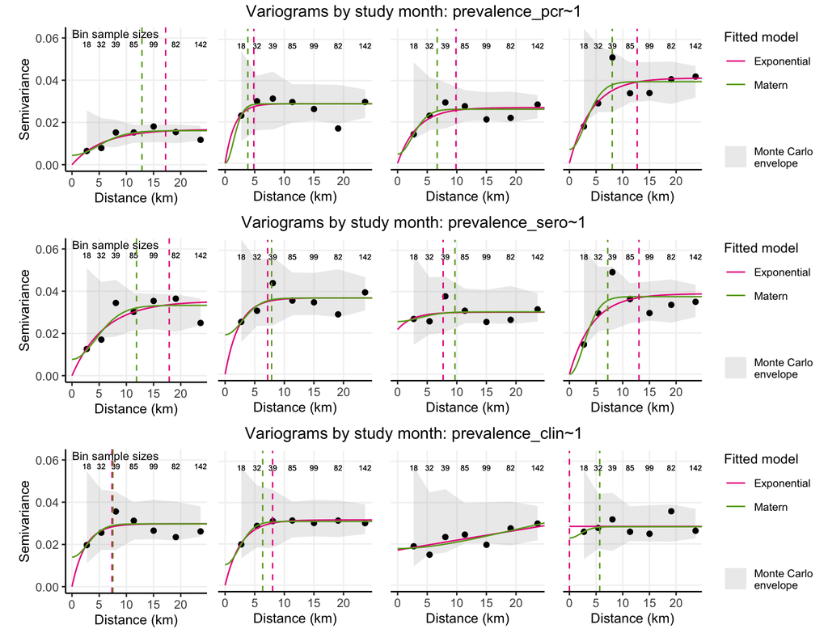

```r
## plot variograms
variog_colors <- c(#"Sph" = RColorBrewer::brewer.pal(n = 8, name = "Dark2")[7],
                   "Exp" = RColorBrewer::brewer.pal(n = 8, name = "Dark2")[4],
                   "Mat" = RColorBrewer::brewer.pal(n = 8, name = "Dark2")[5])

## `get_variog_plot`: plots variograms across 4 survey time points
# returns figure containing 4 variogram plots, one for each survey point
get_variog_plot <- function(permute_results, variog_line, variog_stats, variog_expvar, input_title){

  # initialize container to save plots
  variog_plot_list <- list()

  for(s in survey_list){

    temp_permute <- permute_results %>% filter(survey == s)
    temp_line <- variog_line %>% filter(survey == s)
    temp_stats <- variog_stats %>% filter(survey == s)
    temp_expvar <- variog_expvar %>% filter(survey == s)

    # create variogram plot of points and each model fit
    temp_plot <- ggplot() +
      geom_ribbon(data = temp_permute,
                  aes(x = dist, ymin = q0.025, ymax = q0.975, fill = fill_flag),
                  alpha = 0.3) +
      geom_point(data = temp_expvar, aes(x = dist, y = gamma)) + # empirical variog, does not depend on model
      geom_text(data = temp_expvar, aes(x = dist, y = 0.06*0.95, label = np),
                size = 2) + # empirical variog, does not depend on model
      geom_line(data = temp_line, aes(x = dist, y = gamma, color = model)) +
      geom_vline(data = temp_stats, aes(xintercept = effrange, color = model),
                 lty = "dashed", show.legend = FALSE) +
      scale_color_manual(values = variog_colors,
                         labels = c("Exp" = "Exponential", "Mat" = "Matern")) + #, "Sph" = "Spherical")) +
      scale_fill_manual(values = c("1" = "grey"), labels = c("1" = "Monte Carlo\nenvelope")) +
      labs(x = "Distance (km)",
           y = "Semivariance",
           color = "Fitted model",
           fill = "") +
      coord_cartesian(x = c(0, max(temp_expvar %>% pull(dist))),
                      y = c(0, 0.062)) +
      theme_classic() +
      theme(title = element_text(size = 10),
            panel.grid.major = element_line(color = "grey95"),
            legend.position = "none") +
      guides(fill  = guide_legend(order = 2),
             color = guide_legend(order = 1))

    ## modifications based on survey # (for formatting)
    if(s != 0){
      temp_plot <- temp_plot +
        theme(axis.title.y = element_blank(),
              axis.text.y = element_blank(),
              axis.ticks.y = element_blank(),
              axis.line.y = element_blank())
    }

    if(s == 0){
      temp_plot <- temp_plot +
        geom_text(aes(x = 8, y = 0.062), label = "Bin sample sizes", size = 3) +
        theme(plot.margin = unit(c(0.3,0,0.3,1), 'lines'))
    }

    if(s == 36){
      temp_plot <- temp_plot +
        theme(legend.position = "right",
              legend.title = element_text(size = 10),
              legend.text = element_text(size = 8))
    }

    variog_plot_list <- c(variog_plot_list, list(temp_plot))
  }

  variog_plot <- arrangeGrob(grobs = variog_plot_list, nrow = 1, widths = c(1.2,1,1,1.6),
                             top = input_title)
  return(variog_plot)
}

variog_plots <- lapply(c("prevalence_pcr~1", "prevalence_sero~1", "prevalence_clin~1"),
                       function(x){
                         get_variog_plot(
                           permute_results = variog_perm_results_df %>% filter(formula == x),
                           variog_expvar = variog_expvar_df %>% filter(formula == x),
                           variog_line = variog_line_df %>% filter(formula == x),
                           variog_stats = variog_stats_df %>% filter(formula == x),
                           input_title = paste0("Variograms by study month: ", x)
                          )})
do.call(grid.arrange, args = c(variog_plots, ncol = 1))
```

Calculation of the variogram depends on the assumption that the data does not have systematic surface trends (stationarity). Although it is generally difficult to distinguish between trends and autocorrelation (see example [here](https://pro.arcgis.com/en/pro-app/latest/help/analysis/geostatistical-analyst/understanding-how-to-remove-trends-from-the-data.htm)), it is typical to check for strong trends with a simple model. Here we detrend by latitude and longitude with a simple linear model; variograms are fairly similar to the non-residualized version above, indicating that there is not a strong east-west or north-south trend in this data.

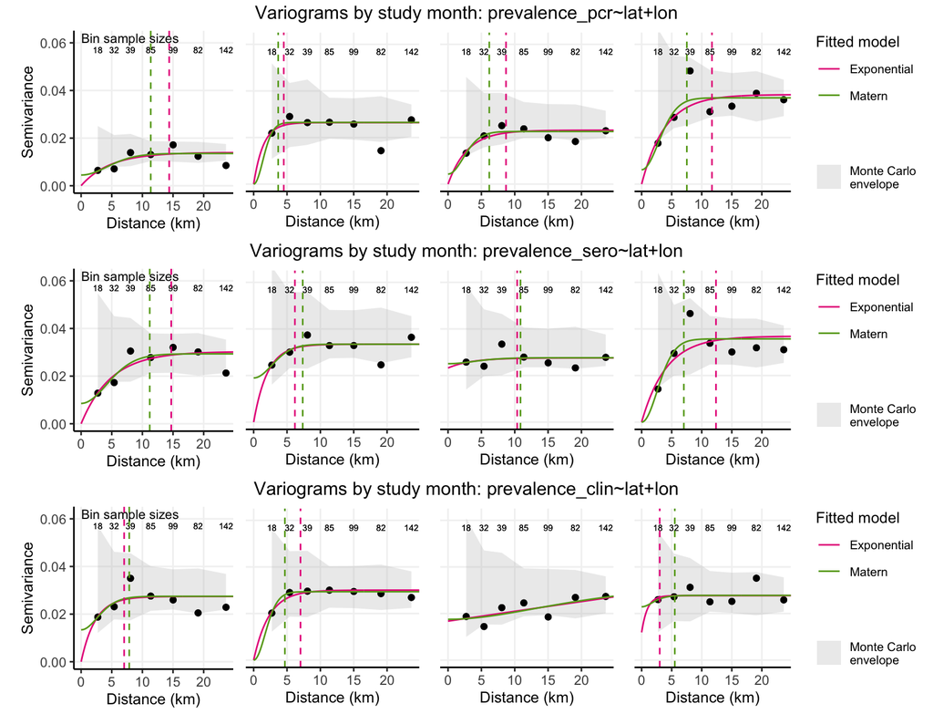

```r
variog_plots_resid <- lapply(c("prevalence_pcr~lat+lon", "prevalence_sero~lat+lon", "prevalence_clin~lat+lon"),
                             function(x){
                               get_variog_plot(
                                 permute_results = variog_perm_results_df %>% filter(formula == x),
                                 variog_expvar = variog_expvar_df %>% filter(formula == x),
                                 variog_line = variog_line_df %>% filter(formula == x),
                                 variog_stats = variog_stats_df %>% filter(formula == x),
                                 input_title = paste0("Variograms by study month: ", x)
                                )})
do.call(grid.arrange, args = c(variog_plots_resid, ncol = 1))
```